# Final Project of AI Course

Rasta Tadayon Tahmasebi

810196436

# Predicting Cellphone Device Prices Based on Real Dataset

## Breif Description of the Project

In this final project the objective is predicting the price of cellphone devices using a real dataset provided by Divar. The dataset can be seen [here](https://research.cafebazaar.ir/visage/divar_datasets/). Divar is an online shop which people can put their goods for sale. This dataset is in persian and has the following columns:

- brand : This feature specifies the device brand. this field consists of categorical values.
- city : The city where the ad was published. this field consists of categorical values.
- title : Shows the title of the ad. Each ad has a title and a description field. This field is in Persian.
- desc : Shows the description of the ad. This field is in Persian as well.
- image_count : The number of images uploaded for the ad by the ad owner. This field consists of numeric values.
- created_at : The day and hour in which the ad was created. This field is in English and has string values.
- price : The price of the device set by the ad owner. This field consists of numeric values but they are not all consistant because they have been set by the users. Some of the values are specified by -1. Thes values will be predicted in the end with the best model that has been achieved.

```python
from __future__ import unicode_literals
import numpy as np
import pandas as pd
from hazm import *
from nltk.tokenize import RegexpTokenizer
import matplotlib.pyplot as plt
from unidecode import unidecode
import math

from sklearn.linear_model import LinearRegression
from sklearn.metrics import mean_squared_error
from sklearn.metrics import mean_absolute_error
from sklearn.neighbors import KNeighborsRegressor
from sklearn.ensemble import RandomForestRegressor
from sklearn.neural_network import MLPRegressor
import lightgbm as lgb

from mpl_toolkits.mplot3d import Axes3D
import re
```

```python
raw_dataset = pd.read_csv('mobile_phone_dataset.csv')
```

The raw dataset looks like this:

```python
raw_dataset
```

|  | Unnamed: 0 | brand | city | title | desc | image_count | created_at | price |
| --- | --- | --- | --- | --- | --- | --- | --- | --- |
| 0 | 0 | Nokia::نوکیا | Qom | نوکیا6303 | سلام.یه گوشیه6303سالم که فقط دوتا خط کوچیک رو ... | 2 | Wednesday 07AM | 60000 |
| 1 | 1 | Apple::اپل | Tehran | ایفون ٥اس٣٢گیگ | درحد نو سالم اصلى بدون ضربه مهلت تست میدم | 0 | Wednesday 11AM | 1150000 |
| 2 | 2 | Samsung::سامسونگ | Mashhad | سامسونگ j5 | گوشى بسیار بسیار تمیز و فقط سه هفته کارکرده و ... | 2 | Wednesday 02PM | 590000 |
| 3 | 3 | Apple::اپل | Karaj | گرى 5s ایفون 32گیگ | گلس پشت و رو .کارت اپل ای دی. لوازم جانبی اصلی... | 3 | Wednesday 04PM | 1100000 |
| 4 | 4 | Samsung::سامسونگ | Tehran | galaxy S5 Gold در حد آک | کاملا تمیز و بدون حتی 1 خط و خش\nبه همراه گلاس... | 2 | Friday 01PM | 900000 |
| ... | ... | ... | ... | ... | ... | ... | ... | ... |
| 59184 | 62171 | Apple::اپل | Tehran | گوشی موبایل ایفون(4S (32GB | گوشی موبایل ایفون 4S\n32 گیگ سفید سالم دکمه هو... | 3 | Tuesday 03PM | 500000 |
| 59185 | 62172 | LG::ال‌جی | Mashhad | گوشی ال جی k10تمیزومرتب بدون خط وخش | گوشی ال جی سالم وبدون کوچکترین ایرادوبدون خط و... | 3 | Tuesday 05PM | 520000 |
| 59186 | 62173 | Apple::اپل | Tehran | /١٦gig/5s/گلد | جعبه ولوازم LLAاصل/بدون خط وخش/باز نشده/سالم. | 2 | Wednesday 11AM | 720000 |
| 59187 | 62174 | Samsung::سامسونگ | Tehran | گلکسی galaxy s4 i9500 | سالم و تمیز با لوازم\nاندروید 5. باتری اورجینا... | 2 | Thursday 09AM | 475000 |
| 59188 | 62175 | Sony::سونی | Mashhad | سونی Z2فورجی سفیدD6503 | فروش یا معاوضه فوری فوری\nسفید تمیز همراه با گ... | 0 | Thursday 11AM | 650000 |

59189 rows × 8 columns

```python
raw_dataset = raw_dataset.drop(columns=['Unnamed: 0'])
```

The devices in the dataset all have one of the following 9 brands. The brand names are both in Farsi and in English. In this part the values are replaced by the English values only to make working with the values easier.

```python
raw_dataset['brand'].unique()
```

```
array(['Nokia::نوکیا', 'Apple::اپل', 'Samsung::سامسونگ', 'Huawei::هوآوی',
       'LG::ال\u200cجی', 'ZTE::زدتی\u200cای', 'Sony::سونی',
       'HTC::اچ\u200cتی\u200cسی', 'Lenovo::لنوو'], dtype=object)
```

```python
raw_dataset['brand'].replace({'Nokia::نوکیا':'Nokia', 'Apple::اپل':'Apple', 'Samsung::سامسونگ':'Samsung',
                            'Huawei::هوآوی':'Huawei', 'LG::ال\u200cجی': 'LG', 'ZTE::زدتی\u200cای':'ZTE',
                            'Sony::سونی':'Sony', 'HTC::اچ\u200cتی\u200cسی':'HTC', 'Lenovo::لنوو':'Lenovo'},
                            inplace=True)
```

```python
raw_dataset.head(5)
```

|  | brand | city | title | desc | image_count | created_at | price |
| --- | --- | --- | --- | --- | --- | --- | --- |
| 0 | Nokia | Qom | نوکیا6303 | سلام.یه گوشیه6303سالم که فقط دوتا خط کوچیک رو ... | 2 | Wednesday 07AM | 60000 |
| 1 | Apple | Tehran | ایفون ٥اس٣٢گیگ | درحد نو سالم اصلى بدون ضربه مهلت تست میدم | 0 | Wednesday 11AM | 1150000 |
| 2 | Samsung | Mashhad | سامسونگ j5 | گوشى بسیار بسیار تمیز و فقط سه هفته کارکرده و ... | 2 | Wednesday 02PM | 590000 |
| 3 | Apple | Karaj | گرى 5s ایفون 32گیگ | گلس پشت و رو .کارت اپل ای دی. لوازم جانبی اصلی... | 3 | Wednesday 04PM | 1100000 |
| 4 | Samsung | Tehran | galaxy S5 Gold در حد آک | کاملا تمیز و بدون حتی 1 خط و خش\nبه همراه گلاس... | 2 | Friday 01PM | 900000 |

## Brand Distribution

In the given dataset all of the brands do not have the same number of representation. In this part number of devices for each brand is shown:

```python
def get_brand_distribution(data):
    brand_number = {}
    unique_brands = data['brand'].unique()
    for brand in unique_brands:
        brand_number[brand] = sum(data['brand'] == brand)

    plt.bar(brand_number.keys(), brand_number.values())
    plt.xticks(rotation = 90)
    plt.xlabel('brand')
    plt.ylabel('number of devices')
    plt.title('Distribution of devices over brands')
    plt.show()
```

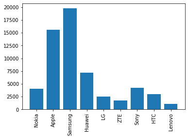

```python
get_brand_distribution(raw_dataset)
```

As is observable the number of devices in each brand vary quite severely. Samsung has around 20 thousand devices whereas Lenovo has less than 25 hundred devices for sale.

## Price Correction

The prices for each brand vary in different ranges. Also besides the -1 values (which are going to be predicted in the end) there are price values which are not consistant. The prices are in Toman unit. It is obvious than no phone can cost 25 tomans. In this part the prices will be set to resonable values based on the intuition gathered from the plots bellow.

The price range of 25 to 3000 tomans is most possibly an invalid range. For this range of price the number of devices for each brand is plotted bellow:

To decide what is the reasonable thing to do with the prices in those range we need to know how many devices for each brand is in that range and which price is most common within that range. To observe this the following graphs are plotted.

```python
def get_price_density_per_brand(dataset):
    unique_brands = dataset['brand'].unique()
    for brand in unique_brands:
        plt.title(brand + ' Price')
        data = dataset[dataset['brand'] == brand]
        plt.hist(data['price'], color = 'blue', edgecolor = 'black',
             bins = int(180/5))
        plt.xticks(rotation = 90)
        plt.show()
```

For each brand we will observe the price ranges in total.(excluding the -1 values of price)

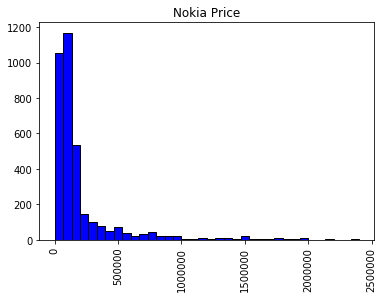

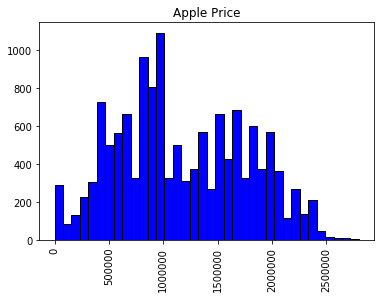

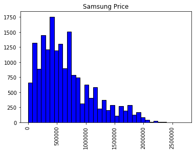

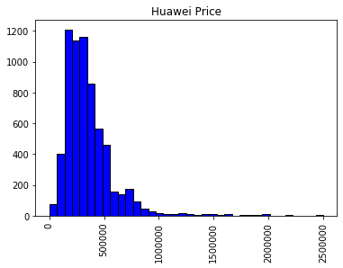

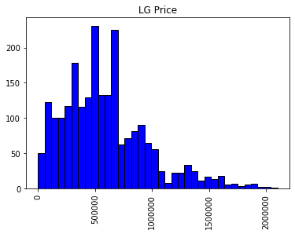

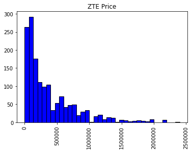

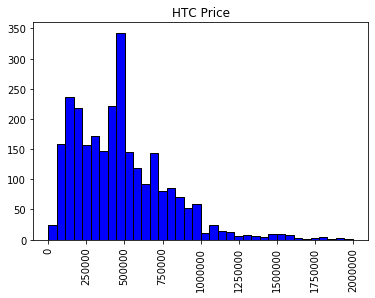

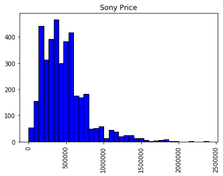

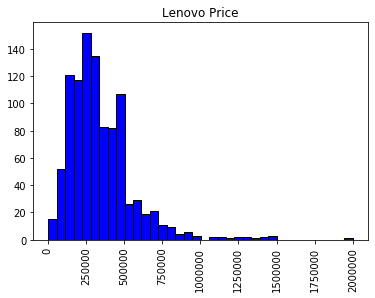

```python
get_price_density_per_brand(raw_dataset[raw_dataset['price'] != -1])
```

```python
def get_box_plot_per_brand(dataset):
    unique_brands = dataset['brand'].unique()
    for brand in unique_brands:
        data = dataset[dataset['brand'] == brand]
        plt.boxplot(data['price'])
        plt.title('boxplot of price for '+ brand)
        plt.show()
```

In the following section box plots of the prices for each brands are shown which are consistant with the distribution plots in the previous section.

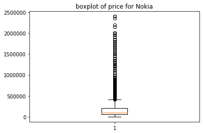

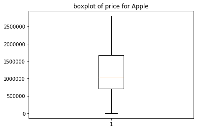

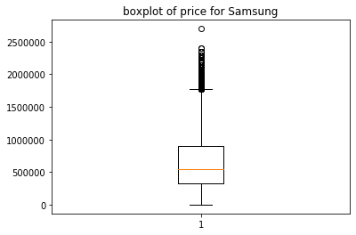

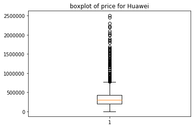

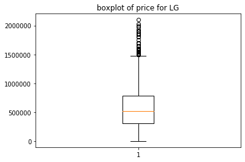

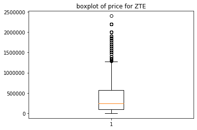

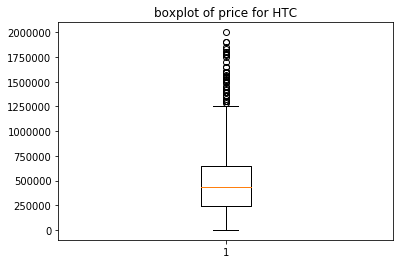

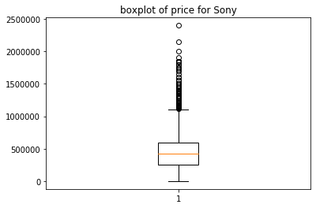

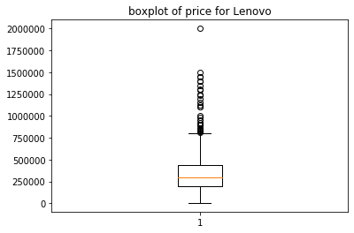

```python
get_box_plot_per_brand(raw_dataset[raw_dataset['price'] != -1])
```

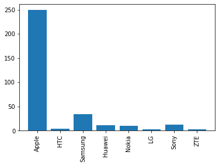

```python
bad_price = raw_dataset[raw_dataset['price'] > 25]
bad_price = bad_price[bad_price['price'] < 3000]
get_brand_distribution(bad_price)
```

After acknowledging which brands have the most 'wrong prices', distribution of the 'bad price' devices for each brand is important and necessary for choosing the right action to apply to this price range. Again for each brand the 'bad prices' are as follows:

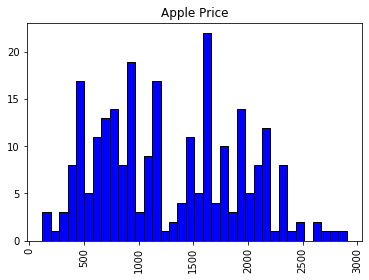

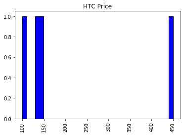

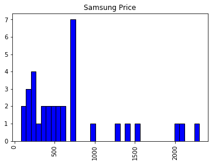

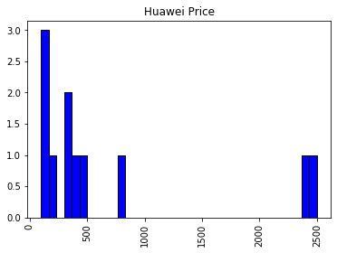

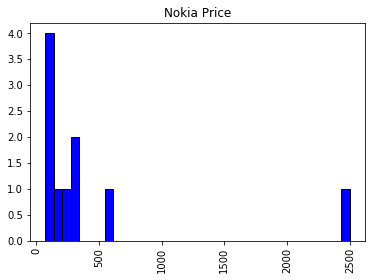

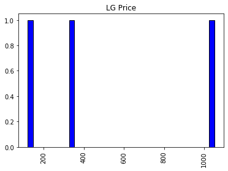

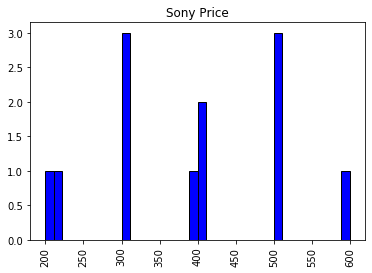

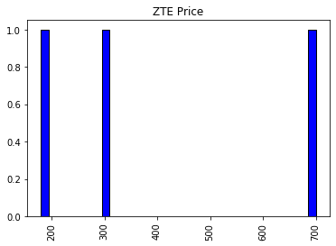

```python
get_price_density_per_brand(bad_price)
```

The plots above give us a general idea about how the prices are according to the device brand. Now for correcting the wrong prices in the dataset we will act like this:

As can be observed from the plots above the prices in the range of 25 and 3000 most probably should have been written as 25000 through 3000000 (multiplied by 1000) because the multiplied numbers mostly fall in the most common price ranges for each brand. Therefore we will multiply the prices of the devices within this range by 1000.

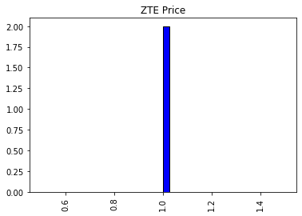

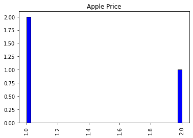

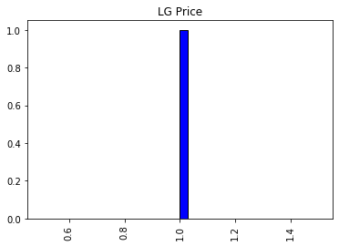

```python
bellow_25 = raw_dataset[raw_dataset['price'] < 25]
bellow_25 = bellow_25[bellow_25['price'] >= 0]
get_price_density_per_brand(bellow_25)
```

What is left of probably invalid prices are prices bellow 25 tomans or higher than 3000 tomans and lower than 25000 tomans.

The number of devices with prices lower than 25 are very small and therefore negligible so these devices are removed from the dataset.

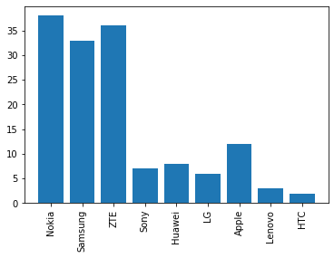

```
145
```

```python
over_3000_under_25000 = raw_dataset[raw_dataset['price'] > 3000]
over_3000_under_25000 = over_3000_under_25000[over_3000_under_25000['price'] < 25000]
get_brand_distribution(over_3000_under_25000)
len(over_3000_under_25000)
```

There are only 145 devices with price range between 3000 and 25000 and since it is not quite obvious what these device's prices must have been they are just dropped from the dataset as well. Now most likely the devices left in the dataset have valid prices.

```python
def fix_price(dataset):
    dataset['price'] = dataset['price'].apply(lambda x : 1000*x if (25 <= x <= 3000) else x)
    dataset['price'] = dataset['price'].apply(lambda x : None if ((0 <= x < 25) or (3000 < x < 25000)) else x)
    dataset = dataset.replace(to_replace='None', value=np.nan).dropna()
    return dataset
```

```python
corrected_price = fix_price(raw_dataset)
```

```python
corrected_price = corrected_price.reset_index(drop=True)
```

## Extracting data from 'desc' and 'title' columns

### Normalization

As mentioned before the 'desc' and 'title' columns contain data in Persian which were entered by the ad owner therefore the title column may not have the actual title of the cellphone device as well as the description may have misspelled words or words that have been written in the informal format of the Persian language. To be able to use these columns some kind of feature extraction should be applied. The following explains what kinds of normalization techniques were used in this project.

Since we are working with Farsi text we need libraries that can help process it. For this reason the [Hazm](https://www.sobhe.ir/hazm/docs/index.html) python library is used in this part of the project.

These columns may contain sentences therefore may contain punctuation marks that do not add any information. In this part, firstly the punctuation marks where deleted and replaced with space character.

### Removing punctuation marks

```python
def punctuation_remover(sentence):
    tokenizer = RegexpTokenizer(r'\w+')
    sentence = tokenizer.tokenize(sentence)
    return ' '. join(word for word in sentence)

corrected_price['desc'] = corrected_price['desc'].apply(lambda x : punctuation_remover(x))
corrected_price['title'] = corrected_price['title'].apply(lambda x : punctuation_remover(x))
```

The resulting dataframe is shown bellow.

```python
corrected_price
```

|  | brand | city | title | desc | image_count | created_at | price |
| --- | --- | --- | --- | --- | --- | --- | --- |
| 0 | Nokia | Qom | نوکیا6303 | سلام یه گوشیه6303سالم که فقط دوتا خط کوچیک رو ... | 2 | Wednesday 07AM | 60000.0 |
| 1 | Apple | Tehran | ایفون ٥اس٣٢گیگ | درحد نو سالم اصلى بدون ضربه مهلت تست میدم | 0 | Wednesday 11AM | 1150000.0 |
| 2 | Samsung | Mashhad | سامسونگ j5 | گوشى بسیار بسیار تمیز و فقط سه هفته کارکرده و ... | 2 | Wednesday 02PM | 590000.0 |
| 3 | Apple | Karaj | گرى 5s ایفون 32گیگ | گلس پشت و رو کارت اپل ای دی لوازم جانبی اصلی م... | 3 | Wednesday 04PM | 1100000.0 |
| 4 | Samsung | Tehran | galaxy S5 Gold در حد آک | کاملا تمیز و بدون حتی 1 خط و خش به همراه گلاس ... | 2 | Friday 01PM | 900000.0 |
| ... | ... | ... | ... | ... | ... | ... | ... |
| 59033 | Apple | Tehran | گوشی موبایل ایفون 4S 32GB | گوشی موبایل ایفون 4S 32 گیگ سفید سالم دکمه هوم... | 3 | Tuesday 03PM | 500000.0 |
| 59034 | LG | Mashhad | گوشی ال جی k10تمیزومرتب بدون خط وخش | گوشی ال جی سالم وبدون کوچکترین ایرادوبدون خط و... | 3 | Tuesday 05PM | 520000.0 |
| 59035 | Apple | Tehran | ١٦gig 5s گلد | جعبه ولوازم LLAاصل بدون خط وخش باز نشده سالم | 2 | Wednesday 11AM | 720000.0 |
| 59036 | Samsung | Tehran | گلکسی galaxy s4 i9500 | سالم و تمیز با لوازم اندروید 5 باتری اورجینال ... | 2 | Thursday 09AM | 475000.0 |
| 59037 | Sony | Mashhad | سونی Z2فورجی سفیدD6503 | فروش یا معاوضه فوری فوری سفید تمیز همراه با گا... | 0 | Thursday 11AM | 650000.0 |

59038 rows × 7 columns

### Tokeninzing the sentences

After the punctuation marks are removed the sentences should be broken down to words, therefore we need to tokenize them. For this task the word tokenizer of the Hazm library was used which tokenizes the sentences. However since we are working with real data and all the words are not seperated correctly, some of the tokens are not necessarly one word.

The `WordTokenizer` returns a lits of tokenized elements. The dataframe after tokenizing is shown bellow.

```python
tokenizer = WordTokenizer()
normalized_dataset = corrected_price.copy()
normalized_dataset['title'] = normalized_dataset['title'].apply(lambda x : tokenizer.tokenize(x))
normalized_dataset['desc'] = normalized_dataset['desc'].apply(lambda x : tokenizer.tokenize(x))
normalized_dataset
```

|  | brand | city | title | desc | image_count | created_at | price |
| --- | --- | --- | --- | --- | --- | --- | --- |
| 0 | Nokia | Qom | [نوکیا, 6303] | [سلام, یه, گوشیه, 6303, سالم, که, فقط, دوتا, خ... | 2 | Wednesday 07AM | 60000.0 |
| 1 | Apple | Tehran | [ایفون, ٥اس, ٣٢, گیگ] | [درحد, نو, سالم, اصلى, بدون, ضربه, مهلت, تست, ... | 0 | Wednesday 11AM | 1150000.0 |
| 2 | Samsung | Mashhad | [سامسونگ, j5] | [گوشى, بسیار, بسیار, تمیز, و, فقط, سه, هفته, ک... | 2 | Wednesday 02PM | 590000.0 |
| 3 | Apple | Karaj | [گرى, 5s, ایفون, 32, گیگ] | [گلس, پشت, و, رو, کارت, اپل, ای, دی, لوازم, جا... | 3 | Wednesday 04PM | 1100000.0 |
| 4 | Samsung | Tehran | [galaxy, S5, Gold, در, حد, آک] | [کاملا, تمیز, و, بدون, حتی, 1, خط, و, خش, به, ... | 2 | Friday 01PM | 900000.0 |
| ... | ... | ... | ... | ... | ... | ... | ... |
| 59033 | Apple | Tehran | [گوشی, موبایل, ایفون, 4S, 32, GB] | [گوشی, موبایل, ایفون, 4S, 32, گیگ, سفید, سالم,... | 3 | Tuesday 03PM | 500000.0 |
| 59034 | LG | Mashhad | [گوشی, ال, جی, k, 10, تمیزومرتب, بدون, خط, وخش] | [گوشی, ال, جی, سالم, وبدون, کوچکترین, ایرادوبد... | 3 | Tuesday 05PM | 520000.0 |
| 59035 | Apple | Tehran | [١٦, gig, 5s, گلد] | [جعبه, ولوازم, LLAاصل, بدون, خط, وخش, باز, نشد... | 2 | Wednesday 11AM | 720000.0 |
| 59036 | Samsung | Tehran | [گلکسی, galaxy, s4, i, 9500] | [سالم, و, تمیز, با, لوازم, اندروید, 5, باتری, ... | 2 | Thursday 09AM | 475000.0 |
| 59037 | Sony | Mashhad | [سونی, Z2فورجی, سفیدD, 6503] | [فروش, یا, معاوضه, فوری, فوری, سفید, تمیز, همر... | 0 | Thursday 11AM | 650000.0 |

59038 rows × 7 columns

### Removing stop words

After tokenizing stop words should be removed. The reason why stop words are removed is because we want to obtain valuable and informative words from the dataset and stop words are words that do not convey any information such as 'از' , 'با', 'و' and more other words like that. So hopefully after removing these words what is left of the data will be useful words.

```python
stop_words = stopwords_list()
def stop_words_remover(sentence):
    for word in stop_words:
        if sentence != None and word in sentence:
            sentence = list(filter((word).__ne__, sentence))
    return sentence
```

```python
normalized_dataset['title'] = normalized_dataset['title'].apply(lambda x : stop_words_remover(x))
normalized_dataset['desc'] = normalized_dataset['desc'].apply(lambda x : stop_words_remover(x))
```

```python
normalized_dataset
```

|  | brand | city | title | desc | image_count | created_at | price |
| --- | --- | --- | --- | --- | --- | --- | --- |
| 0 | Nokia | Qom | [نوکیا, 6303] | [سلام, یه, گوشیه, 6303, سالم, دوتا, خط, کوچیک,... | 2 | Wednesday 07AM | 60000.0 |
| 1 | Apple | Tehran | [ایفون, ٥اس, ٣٢, گیگ] | [درحد, نو, سالم, اصلى, ضربه, مهلت, تست, میدم] | 0 | Wednesday 11AM | 1150000.0 |
| 2 | Samsung | Mashhad | [سامسونگ, j5] | [گوشى, تمیز, هفته, کارکرده, آک] | 2 | Wednesday 02PM | 590000.0 |
| 3 | Apple | Karaj | [گرى, 5s, ایفون, 32, گیگ] | [گلس, کارت, اپل, ای, دی, لوازم, جانبی, اصلی, م... | 3 | Wednesday 04PM | 1100000.0 |
| 4 | Samsung | Tehran | [galaxy, S5, Gold, آک] | [تمیز, 1, خط, خش, همراه, گلاس, قاب, محافظ] | 2 | Friday 01PM | 900000.0 |
| ... | ... | ... | ... | ... | ... | ... | ... |
| 59033 | Apple | Tehran | [گوشی, موبایل, ایفون, 4S, 32, GB] | [گوشی, موبایل, ایفون, 4S, 32, گیگ, سفید, سالم,... | 3 | Tuesday 03PM | 500000.0 |
| 59034 | LG | Mashhad | [گوشی, ال, جی, k, 10, تمیزومرتب, خط, وخش] | [گوشی, ال, جی, سالم, وبدون, کوچکترین, ایرادوبد... | 3 | Tuesday 05PM | 520000.0 |
| 59035 | Apple | Tehran | [١٦, gig, 5s, گلد] | [جعبه, ولوازم, LLAاصل, خط, وخش, نشده, سالم] | 2 | Wednesday 11AM | 720000.0 |
| 59036 | Samsung | Tehran | [گلکسی, galaxy, s4, i, 9500] | [سالم, تمیز, لوازم, اندروید, 5, باتری, اورجینا... | 2 | Thursday 09AM | 475000.0 |
| 59037 | Sony | Mashhad | [سونی, Z2فورجی, سفیدD, 6503] | [فروش, معاوضه, فوری, فوری, سفید, تمیز, همراه, ... | 0 | Thursday 11AM | 650000.0 |

59038 rows × 7 columns

### Lemmatizing

Since in each language words with the nearly same meaning have different form we need some sort of algorithm that returns the base form of the words. This is specially helpful when using techniques such as **bag of words** where the number of repeated words are important so getting the root form of the words can be important. Two main algorithms that do this job are **Lemmatizing** and **Stemming**. In this section of the project Lemmatize was applied to the data since we saw in the previous projects the advantages it had over Stemming.

For applying lemmitize to Persian text `Lemmatizer()` from the Hazm library was used.

```python
lemmatizer = Lemmatizer()
def lemmatizing (sentence):

    for i in range(len(sentence)):
        sentence[i] = lemmatizer.lemmatize(sentence[i])
    return sentence
```

The datafram after lemmatization is like the following:

```python
normalized_dataset['title'] = normalized_dataset['title'].apply(lambda x : lemmatizing(x))
normalized_dataset['desc'] = normalized_dataset['desc'].apply(lambda x : lemmatizing(x))
normalized_dataset
```

[output not shown]

59038 rows × 7 columns

### Making all numbers uniform

```python
persian_numbers = ['۰', '۱', '۲', '۳', '۴', '۵', '۶', '۷', '۸', '۹']
arabic_numbers = ['٩', '٨', '٧', '٦', '٥', '٤', '٣', '٢', '١','٠']
def unify_numbers(sentence):
    for i in range(len(sentence)):
        for j in range(len(persian_numbers)):
            if(persian_numbers[j] in sentence[i]):
                sentence[i] = sentence[i].replace(persian_numbers[j], str(j))
            if(arabic_numbers[j] in sentence[i]):
                sentence[i] = sentence[i].replace(arabic_numbers[j], str(j))
    return sentence
```

```python
normalized_dataset['title'] = normalized_dataset['title'].apply(lambda x : unify_numbers(x))
normalized_dataset['desc'] = normalized_dataset['desc'].apply(lambda x : unify_numbers(x))
normalized_dataset
```

|  | brand | city | title | desc | image_count | created_at | price |
| --- | --- | --- | --- | --- | --- | --- | --- |
| 0 | Nokia | Qom | [نوکیا, 6303] | [سلام, یه, گوشیه, 6303, سالم, دوتا, خط, کوچیک,... | 2 | Wednesday 07AM | 60000.0 |
| 1 | Apple | Tehran | [ایفون, 4اس, 67, گیگ] | [درحد, نو, سالم, اصلى, ضربه, مهلت, تست, میدم] | 0 | Wednesday 11AM | 1150000.0 |
| 2 | Samsung | Mashhad | [سامسونگ, j5] | [گوشى, تمیز, هفته, کارکرده, آک] | 2 | Wednesday 02PM | 590000.0 |
| 3 | Apple | Karaj | [گرى, 5s, ایفون, 32, گیگ] | [گلس, کارت, اپل, ای, دی, لوازم, جانبی, اصل, مع... | 3 | Wednesday 04PM | 1100000.0 |
| 4 | Samsung | Tehran | [galaxy, S5, Gold, آک] | [تمیز, 1, خط, خش, همراه, گلاس, قاب, محافظ] | 2 | Friday 01PM | 900000.0 |
| ... | ... | ... | ... | ... | ... | ... | ... |
| 59033 | Apple | Tehran | [گوش, موبایل, ایفون, 4S, 32, GB] | [گوش, موبایل, ایفون, 4S, 32, گیگ, سفید, سالم, ... | 3 | Tuesday 03PM | 500000.0 |
| 59034 | LG | Mashhad | [گوش, ال, جی, k, 10, تمیزومرتب, خط, وخش] | [گوش, ال, جی, سالم, وبدون, کوچک, ایرادوبدون, خ... | 3 | Tuesday 05PM | 520000.0 |
| 59035 | Apple | Tehran | [83, gig, 5s, گلد] | [جعبه, ولوازم, LLAاصل, خط, وخش, شد#شو, سالم] | 2 | Wednesday 11AM | 720000.0 |
| 59036 | Samsung | Tehran | [گلکسی, galaxy, s4, i, 9500] | [سالم, تمیز, لوازم, اندروید, 5, باتری, اورجینا... | 2 | Thursday 09AM | 475000.0 |
| 59037 | Sony | Mashhad | [سون, Z2فورجی, سفیدD, 6503] | [فروش, معاوضه, فوری, فوری, سفید, تمیز, همراه, ... | 0 | Thursday 11AM | 650000.0 |

59038 rows × 7 columns

## Dataset division

After the normalization is done the datafram is divided into 3 section. The first one is the evaluation set which are the devices with price equal to -1. The second and thirs sections are training and test sets. All the trainings and information gatherings will only happen on the training set. The division of the dataset is being done in this part because in the next we want to gather which words are important are informative so they can be used as features and we do not want to have access to the test set data for that.

```python
eval_set = normalized_dataset[normalized_dataset['price'] == -1]
```

For training and test sets 0.8 of each brand are put into the trainig set and the rest are put into the test set. The reason for this is that we want to have as much of a uniform division as possible since having a training set that has vrey little information on one brand and a lot of information on another brand may cause the model to have a more accurate on one brand than on another one.

```python
def divide(dataset, percentage = 0.8):

    dfs = []
    trainDf = pd.DataFrame()
    testDf = pd.DataFrame()
    data = dataset[dataset['price'] != -1]
    data = data.reset_index(drop=True)
    brands = list(data['brand'].unique())
    for brand in brands:
        df =  data[data['brand'] == brand].copy()
        msk = np.random.rand(df.shape[0]) < percentage
        dfList = []
        dfList.append(df[msk])
        dfList.append(df[~msk])
        dfs.append(dfList)
    for df in dfs:
        trainDf = pd.concat([trainDf,df[0]]).sort_index()
        testDf = pd.concat([testDf, df[1]]).sort_index()

    return trainDf, testDf
```

```python
train_set, test_set = divide(normalized_dataset)
```

## Creating new features

The features given in the dataset are very few (city, created_at, brand) and it is quite obvious that with those features only a good model cannot be trained and features should be extracted from the title and description columns.

For creating features we have to decide which words are most informative and use them as features.

```python
def get_words_counts(data, column):
    train_data = data[data['price'] != -1]
    desc = train_data[column]
    all_descs = []
    for item in desc:
        all_descs += item
    word_counts = {}
    for item in all_descs:
        if(item in word_counts):
            word_counts[item] += 1
        else:
            word_counts[item] = 1
    return word_counts
```

```python
desc_counts = get_words_counts(train_set, 'desc')
title_counts = get_words_counts(train_set, 'title')
sorted_desc_counts = {k: v for k, v in sorted(desc_counts.items(), reverse = True, key=lambda item: item[1])}
sorted_title_counts = {k: v for k, v in sorted(title_counts.items(), reverse = True, key=lambda item: item[1])}
```

To find the best features to add to the dataset the TF-IDF algorithm is used. The dictionaries that were set in the above code section represent the TF part of the algorithm which represents the **Term Frequency** which means how many times each term has repeated in the entire documents. This term should be multiplied by the IDF which stands for **Inverse Document Frequency**. IDF represents the uniqueness of the words which relate to how informative they are. For example the word 'hello' (سلام) is repeated quite a lot but it is not necessarily informative about the device in question.

The IDF term is calculated using the following equation:

$$ IDF = ln(\frac{Total-Number-of-Documents}{Number-of-Documents-with-t-in-it})$$

The following function calculates the TD-IDF values.

```python
def calc_number_of_docs(t, docs):
    num = 0
    for item in docs:
        if(t in item):
            num += 1
    return num
def calc_tfidf(desc_tf, title_tf, dataset):
    descs = list(dataset['desc'])
    titles = list(dataset['title'])
    N_descs = len(descs)
    N_title = len(titles)
    desc_tfidf = {}
    title_tfidf = {}
    for item in desc_tf:
        item_idf = math.log(N_descs/calc_number_of_docs(item, descs))
        desc_tfidf[item] = desc_tf[item]*item_idf
    for item in title_tf:
        item_idf = math.log(N_title/calc_number_of_docs(item, titles))
        title_tfidf[item] = title_tf[item]*item_idf

    return desc_tfidf, title_tfidf
```

After calculating the tf-idf values for all the tokenized words in the description and title columns the words are sorted based on their tf-idf values and 200 words with the highest tf-idf values are selected from the description column to be new features and 100 words from the title column are selected in the same way.

```python
desc_tf_idf, title_tf_idf = calc_tfidf(sorted_desc_counts, sorted_title_counts, train_set)
```

```python
desc_tf_idf = {k: v for k, v in sorted(desc_tf_idf.items(), reverse = True, key=lambda item: item[1])}
title_tf_idf = {k: v for k, v in sorted(title_tf_idf.items(), reverse = True, key=lambda item: item[1])}
```

After setting the features to the dataset the newly added columns are filled with 0's if their respective columns (description and title) did not have that word and are filled with 1 otherwise. The following fuction does this task.

```python
def add_new_features (desc_features, title_features, dataset):
    data = dataset.copy()
    for feature in desc_features:
        data['desc_' + feature] = 0
        data['desc_' + feature] = data['desc'].apply(lambda x : 1 if feature in x else 0 )
    for feature in title_features:
        data['title_' + feature] = 0
        data['title_' + feature] = data['title'].apply(lambda x : 1 if feature in x else 0 )

    return data
```

As mentioned before the datafram has a few categorical features as well. These features are:

- city
- brand
- created at

Since a model can not understand categorical values these values should be encoded. Two ways of encoding these values are: Label encoding and One-Hot encoding. Each of these methode have advantages and disadvantages but since the label encoding methode introduces an ordering into the data and two out of 4 models trained for this project (linear regression and K Nearest Neighbour) are sensetive to the ordering implies by the label encoding, I decided to use one-hot encoding. For one-hot encoding the `get_dummies()` function of the pandas library was used.

```python
def one_hot_encode(data):
    data_one_hot = pd.concat([data,pd.get_dummies(data['city'], prefix='city')],axis=1).drop(['city'],axis=1)
    data_one_hot = pd.concat([data_one_hot,pd.get_dummies(data_one_hot['brand'], prefix='')],axis=1).drop(['brand'],axis=1)
    return data_one_hot
```

```python
def set_number_of_new_features(desc_num, title_num, desc_features, title_features, train_set, test_set, eval_set):
    title_features = list(title_features.keys())[:title_num]
    desc_features = list(desc_features.keys())[:desc_num]
    train_set = add_new_features(desc_features, title_features, train_set)
    test_set = add_new_features(desc_features, title_features, test_set)
    eval_set = add_new_features(desc_features, title_features, eval_set)

    train_set = one_hot_encode(train_set)
    test_set = one_hot_encode(test_set)
    eval_set = one_hot_encode(eval_set)

    train_set.drop(columns=['title', 'desc', 'created_at'], inplace=True)
    test_set.drop(columns=['title', 'desc','created_at'], inplace=True)
    eval_set.drop(columns=['title', 'desc','created_at'], inplace=True)

    return train_set, test_set, eval_set
```

The code in the section above sets the extracted values, one-hot encodes the desired columns and also drops the 'created_at' column. The reason for dropping this colunm is because intuitively we know that price is not related to the day of the week or the hour in which the add was created. I can also show this by calculating the information gain or correlation between this column and the price column. This is not done in this notebook due to lack of time but certainly can be shown.

```python
tfidf_train_set, tfidf_test_set, tfidf_eval_set = set_number_of_new_features(200,100,
                                                                            desc_tf_idf,
                                                                            title_tf_idf,
                                                                            train_set,
                                                                            test_set,
                                                                            eval_set)
```